# Exploring the BRFSS data

## Setup

This report will use the provided dataset of the Behavioural Risk Factor Surveillance system (BRFSS) to put into practice the acquired knowledge in the first specialization of the Statistics with R course, offered by Duke University.

To help us out here, the following packages are loaded in: `dplyr` is used to explore the data and `ggplot2` is used to make the visualizations to help analyse the data.

### Load packages

```r
library(ggplot2)
library(dplyr)
library(statsr)
```

### Load data

The dataset was downloaded from the course page on Coursera and it is saved in the same folder as this markdown file to make it easily accessible from within RStudio. It is loaded into this document using the `load` command.

```r
load("brfss2013.RData")
```

## Part 1: Data

As mentioned before, the BRFSS dataset is used for this exploration into statistics. The accompanying explanatory document gives a good overview of the different variables. For illustrative purposes (although the practicality of it is based on personal opinion), a small piece of code was added to show how many different values each variable contains. For a better overview, the reader is referred to the aforementioned explanatory document.

It does become clear that many of the variables are of the categorical type since there is a limited number of possibilities, which would be unlikely when considering a numerical variable, and even more unlikely when specifically discussing a continuous variable.

It can be seen that almost all the states are incorporated in the survey with only a few missing, even some overseas territories are included. This gives the impression that there is little/no geographical bias in the data and it thus should generalize well to the United States in general. However, the survey is on a voluntary basis and is conducted through random-digit dialling according to the [website of the CDC](https://www.cdc.gov/brfss/about/brfss_faq.htm). This could result that a certain group of people will participate in the survey and that other groups immediately end the connection. It also means that random sampling was used. This also rules out the convenience sampling.

Surveying also means that the study is an observational one. This means that associations within this data cannot immediately be attributed to causation since there might be other factors that are not taken into account. Thus the results can only imply correlation but later research could incorporate an experiment where those other factors can be controlled for.

Finally, the subjects in the survey can be considered as independent since the surveyed population is certainly less than 10% of the complete population. 491,773 people were surveyed and there were definitely more than 49,177,300 people living in the United States in 2013, the year of the survey. The rubric asks for a discussion of random assignment, which seems to not be applicable since this study is an observational one and not an experiment, with the latter such assignment is indeed relevant but not regarding this study and therefore random assignment was not used.

```r
sapply(brfss2013, function(x) length(unique(x)))
```

```
##   X_state    fmonth     idate    imonth      iday     iyear  dispcode
##        55        13       428        13        32         3         3
##     seqno     X_psu  ctelenum  pvtresd1  colghous  stateres  cellfon3
##     33911     33911         2         3         2         2         2
##    ladult  numadult    nummen  numwomen   genhlth  physhlth  menthlth
##         3        19        15        13         6        33        34
##  poorhlth  hlthpln1  persdoc2   medcost  checkup1  sleptim1   bphigh4
##        33         3         4         3         6        28         5
##    bpmeds  bloodcho   cholchk   toldhi2  cvdinfr4  cvdcrhd4  cvdstrk3
##         3         3         5         3         3         3         3
##   asthma3   asthnow  chcscncr  chcocncr  chccopd1  havarth3  addepev2
##         3         3         3         3         3         3         3
##  chckidny  diabete3  veteran3   marital  children     educa   employ1
##         3         5         3         7        21         7         9
##   income2   weight2   height3  numhhol2  numphon2   cpdemo1   cpdemo4
##         9       570       156         3         7         3       101
##  internet  renthom1       sex  pregnant  qlactlm2  useequip     blind
##         3         4         3         3         3         3         3
##    decide  diffwalk  diffdres  diffalon  smoke100  smokday2  stopsmk2
##         3         3         3         3         3         4         3
##  lastsmk2   usenow3   alcday5  avedrnk2  drnk3ge5  maxdrnks  fruitju1
##         9         4        41        49        42        58       119
##    fruit1   fvbeans   fvgreen   fvorang  vegetab1  exerany2  exract11
##       145       115       131       111       131         3        76
##  exeroft1  exerhmm1  exract21  exeroft2  exerhmm2  strength  lmtjoin3
##       127       197        77       119       182       113         3
##  arthdis2  arthsocl  joinpain  seatbelt  flushot6  flshtmy2   tetanus
##         3         4        12         7         3        27         5
##  pneuvac3   hivtst6  hivtstd3  whrtst10  pdiabtst  prediab1  diabage2
##         3         3       387        10         3         4        97
##   insulin  bldsugar  feetchk2  doctdiab  chkhemo3   feetchk   eyeexam
##         3        89        76        47        41        46         6
##   diabeye   diabedu  painact2  qlmentl2  qlstres2   qlhlth2  medicare
##         3         3        18        19        21        25         3
##  hlthcvrg  delaymed  dlyother  nocov121  lstcovrg  drvisits  medscost
##       441         8     10240         3         6        77         4
##  carercvd  medbills  ssbsugar  ssbfrut2  wtchsalt  longwtch  dradvise
##         4         3        94        93         3       180         3
##  asthmage  asattack  aservist  asdrvist  asrchkup  asactlim  asymptom
##        73         3        13        19        25        36         7
```

[output cut: 41 more lines]

```
##         4         6         3         3       550      1091         3
##  X_veglt1   X_frt16   X_veg23 X_fruitex X_vegetex X_totinda  metvl11_
##         3         3         3         4         4         3        34
##  metvl21_   maxvo2_     fc60_  actin11_  actin21_   padur1_   padur2_
##        33       165       159         4         4       199       183
##  pafreq1_  pafreq2_ X_minac11 X_minac21  strfreq_  pamiss1_  pamin11_
##       123       116       791       625       109         6       915
##  pamin21_   pa1min_  pavig11_  pavig21_  pa1vigm_  X_pacat1 X_paindx1
##       677      2741       564       428      1450         5         3
## X_pa150r2 X_pa300r2 X_pa30021 X_pastrng  X_parec1 X_pastae1 X_lmtact1
##         4         4         3         3         5         3         4
## X_lmtwrk1 X_lmtscl1 X_rfseat2 X_rfseat3 X_flshot6 X_pneumo2 X_aidtst3
##         4         5         3         3         3         3         3
##   X_age80
##        68
```

## Part 2: Research questions

**Research quesion 1:**

This can be of interest for seeing if the state someone lives in has in some form or way an (indirect) impact on the number of hours of sleep a male person gets.

**Research quesion 2:**

Is the chance on a bad physical health day higher or lower than 50%?

This question can shine a light on the apparent chance on having a bad physical health day.

**Research quesion 3:**

Is there an apparent relation between having ever being told that blood cholesterol is high and having ever been told that the blood pressure is high?

This answer can be of great value to determine if cholesterol is of effect on blood pressure. Research has found this out a long time ago of course but it would be interesting to see if this data reflects this.

## Part 3: Exploratory data analysis

**Research question 1:**

First, it is handy to see how sleep time is distributed in general.

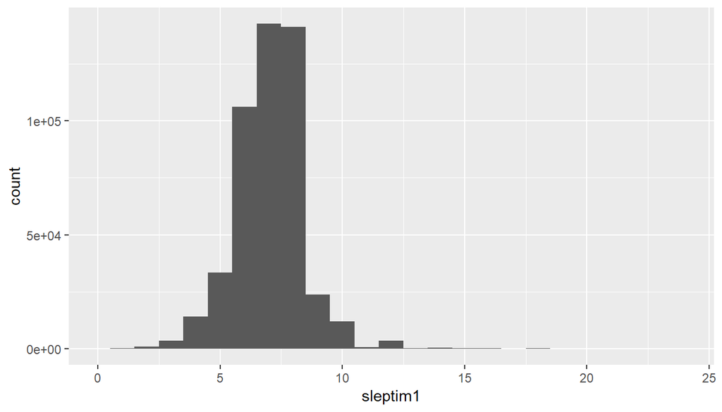

```r
ggplot(brfss2013, aes(sleptim1)) + geom_histogram(binwidth = 1) + coord_cartesian(xlim = c(0,24))
```

```r
summary(brfss2013$sleptim1)
```

```
##    Min. 1st Qu.  Median    Mean 3rd Qu.    Max.    NA's
##   0.000   6.000   7.000   7.052   8.000 450.000    7387
```

The sleep time data seems to be rather normally distributed and the mean and median being very similar also solidifies this claim.

New data frames should be created to test this research question.

```r
sleep_time_cali <- subset(brfss2013, X_state == "California")
sleep_time_NYS <- subset(brfss2013, X_state == "New York")
```

These new data frames should be checked for their distribution and summary statistics.

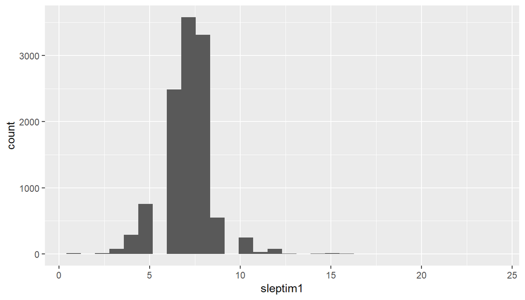

```r
ggplot(sleep_time_cali, aes(sleptim1)) + geom_histogram()
```

```r
summary(sleep_time_cali$sleptim1)
```

```
##    Min. 1st Qu.  Median    Mean 3rd Qu.    Max.    NA's
##   1.000   6.000   7.000   7.057   8.000  24.000      57
```

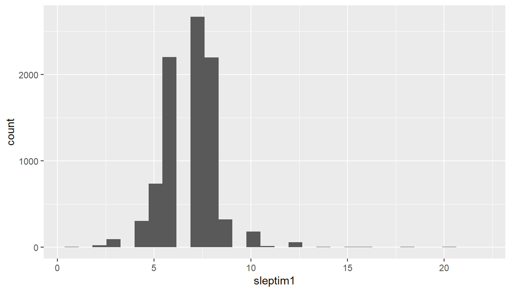

```r
ggplot(sleep_time_NYS, aes(sleptim1)) + geom_histogram()
```

```r
summary(sleep_time_NYS$sleptim1)
```

```
##    Min. 1st Qu.  Median    Mean 3rd Qu.    Max.    NA's
##   1.000   6.000   7.000   6.876   8.000  22.000     147
```

Both the histograms look rather similar and it is not immediately easy to tell if there is a difference between the states. Looking at the summary statistics gives a clearer view of the situation. The median and the quantiles are exactly similar for both states, but this can also be attributed to the fact that the values only take on integer values.

**Research question 2:**

To answer this question, we should determine what a distribution of the number of bad physical days looks like when the chance is 50%. This can be achieved through comparing the mean of the data to what the mean would be when the chance would be 50%.

First, let’s plot the distribution of bad physical days in the dataset

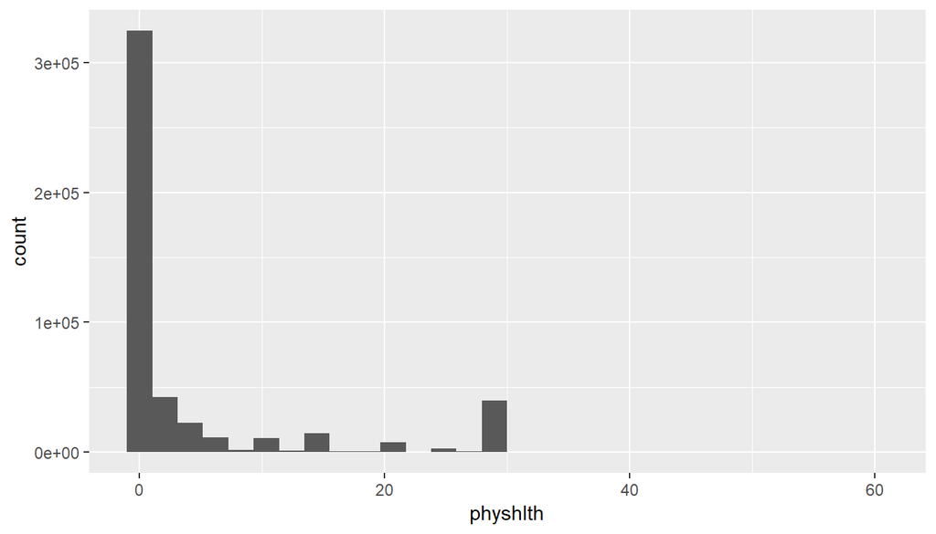

```r
ggplot(brfss2013, aes(physhlth)) + geom_histogram()
```

```r
summary(brfss2013$physhlth)
```

```
##    Min. 1st Qu.  Median    Mean 3rd Qu.    Max.    NA's
##   0.000   0.000   0.000   4.353   3.000  60.000   10957
```

It is clear that most people did not experience a day in the month previous to the survey in which they did not feel physically well. This is substantiated by the median being at 0.

The graph would have a normally distributed or normal shape when the chance would be 50% with the mean being at 15 (half of the days).

**Research question 3:**

To answer this research question, oth variables will be explored and the ratio of yes to no will be calculated

```r
table(brfss2013$toldhi2)
```

```
##
##    Yes     No
## 183501 236612
```

```r
ratio_cholesterol <- 183501 / (183501+236610)
ratio_cholesterol
```

```
## [1] 0.4367917
```

```r
table(brfss2013$bphigh4)
```

```
##
##                                        Yes
##                                     198921
## Yes, but female told only during pregnancy
##                                       3680
##                                         No
##                                     282687
##        Told borderline or pre-hypertensive
##                                       5067
```

```r
ratio_bloodpressure <- 198921 / (198921+282687)
ratio_bloodpressure
```

```
## [1] 0.4130351
```

Small note: For blood pressure, answers diverting from “yes” or “no” were left out for ease of analysis and considering their small numbers, this probably does not have a major effect on the outcome.

The two calculated ratios are very similar. 0.4368 and 0.4130 are close together and this suggests that there is indeed a perceived relationship between high blood pressure and high cholesterol levels. If this research was the first to look into this relationship, it could be used in medical science, but fortunately medical science has looked into this before. Still it provides further proof that there is indeed a relationship.